# Uso de la API del Covid con Pandas

La URL: http://api.covid19api.com/countries

# Instalación librerías

```python
!pip install pandas
```

El ! nos indica que no estamos ejecutando Python, sino Bash. Pandas es una librería de Python especializada en manejar análisis y estructuras de datos. En clases anteriores estuvimos viendo el tipo de estructura de datos en listas, donde los tipos de datos que podemos encontrar son: strings (o cadenas de caracteres), numbers o booleans (datos de verdadero o falso). Hoy veremos la estructura de datos Dataframe.

## Configuración de Pandas

```python
import pandas as pd
```

Ahora, estamos abreviando la importación de pandas como pd.

## Crear variable

```python
url = 'https://api.covid19api.com/countries'
```

Definimos la variable url que pusimos antes, y que Python vea lo que es. Para ello le explicamos a Python que url es = a una cadena de caracteres o strings, motivo por el que van entre comillas.

## Crear Dataframe

De pandas hay una función que se llama read_json, que por es una función para leer JSON (Java Script Object Notation o notación de objetos en java script). Dentro de la función, read_json ponemos : para poner lo que queremos que lea. El URL con los datos está en JSON, son los datos en ese lenguaje.

```python
df = pd.read_json(url)
```

```python
df
```

|  | Country | Slug | ISO2 |
| --- | --- | --- | --- |
| 0 | French Polynesia | french-polynesia | PF |
| 1 | Indonesia | indonesia | ID |
| 2 | Malta | malta | MT |
| 3 | Sao Tome and Principe | sao-tome-and-principe | ST |
| 4 | Haiti | haiti | HT |
| ... | ... | ... | ... |
| 243 | Myanmar | myanmar | MM |
| 244 | Turkey | turkey | TR |
| 245 | Western Sahara | western-sahara | EH |
| 246 | Pitcairn | pitcairn | PN |
| 247 | Tanzania, United Republic of | tanzania | TZ |

248 rows × 3 columns

## Exploracion de la tabla

```python
df.head (6)
```

|  | Country | Slug | ISO2 |
| --- | --- | --- | --- |
| 0 | French Polynesia | french-polynesia | PF |
| 1 | Indonesia | indonesia | ID |
| 2 | Malta | malta | MT |
| 3 | Sao Tome and Principe | sao-tome-and-principe | ST |
| 4 | Haiti | haiti | HT |
| 5 | Poland | poland | PL |

```python
df.tail (2)
```

|  | Country | Slug | ISO2 |
| --- | --- | --- | --- |
| 246 | Pitcairn | pitcairn | PN |
| 247 | Tanzania, United Republic of | tanzania | TZ |

```python
df.info()
```

```
<class 'pandas.core.frame.DataFrame'>
RangeIndex: 248 entries, 0 to 247
Data columns (total 3 columns):
 #   Column   Non-Null Count  Dtype
---  ------   --------------  -----
 0   Country  248 non-null    object
 1   Slug     248 non-null    object
 2   ISO2     248 non-null    object
dtypes: object(3)
memory usage: 5.9+ KB
```

```python
df['Country']
```

```
0                  French Polynesia
1                         Indonesia
2                             Malta
3             Sao Tome and Principe
4                             Haiti
                   ...
243                         Myanmar
244                          Turkey
245                  Western Sahara
246                        Pitcairn
247    Tanzania, United Republic of
Name: Country, Length: 248, dtype: object
```

```python
df['Country'] [66]
```

```
'Somalia'
```

En este caso ponemos corchetes porque estamos trabajando con listas; queremos que nos muestre los datos en una de las columnas del Dataframe, la columna que muestra los países. Si queremos ver un valor de la columna que nos muestra, en un nuevo corchete mencionamos el valor deseado (el país numero 66 en este caso), por eso aparece Somalía.

## Tiempo real

Este es el URL que vamos a usar ahora, por eso ahora le decimos a Python que url_es es igual al url del conjunto de datos solo de España, en este caso.

https://api.covid19.api.com/country/spain/status/confirmed/live

```python
url_es = 'https://api.covid19api.com/country/spain/status/confirmed/live'
```

```python
df_es = pd.read_json(url_es)
df_es
```

|  | Country | CountryCode | Province | City | CityCode | Lat | Lon | Cases | Status | Date |
| --- | --- | --- | --- | --- | --- | --- | --- | --- | --- | --- |
| 0 | Spain | ES |  |  |  | 40.46 | -3.75 | 0 | confirmed | 2020-01-22 00:00:00+00:00 |
| 1 | Spain | ES |  |  |  | 40.46 | -3.75 | 0 | confirmed | 2020-01-23 00:00:00+00:00 |
| 2 | Spain | ES |  |  |  | 40.46 | -3.75 | 0 | confirmed | 2020-01-24 00:00:00+00:00 |
| 3 | Spain | ES |  |  |  | 40.46 | -3.75 | 0 | confirmed | 2020-01-25 00:00:00+00:00 |
| 4 | Spain | ES |  |  |  | 40.46 | -3.75 | 0 | confirmed | 2020-01-26 00:00:00+00:00 |
| ... | ... | ... | ... | ... | ... | ... | ... | ... | ... | ... |
| 798 | Spain | ES |  |  |  | 40.46 | -3.75 | 11508309 | confirmed | 2022-03-30 00:00:00+00:00 |
| 799 | Spain | ES |  |  |  | 40.46 | -3.75 | 11508309 | confirmed | 2022-03-31 00:00:00+00:00 |
| 800 | Spain | ES |  |  |  | 40.46 | -3.75 | 11551574 | confirmed | 2022-04-01 00:00:00+00:00 |
| 801 | Spain | ES |  |  |  | 40.46 | -3.75 | 11551574 | confirmed | 2022-04-02 00:00:00+00:00 |
| 802 | Spain | ES |  |  |  | 40.46 | -3.75 | 11551574 | confirmed | 2022-04-03 00:00:00+00:00 |

803 rows × 10 columns

```python
df_es.columns
```

```
Index(['Country', 'CountryCode', 'Province', 'City', 'CityCode', 'Lat', 'Lon',
       'Cases', 'Status', 'Date'],
      dtype='object')
```

```python
df_es['Date'].head(2)
```

```
0   2020-01-22 00:00:00+00:00
1   2020-01-23 00:00:00+00:00
Name: Date, dtype: datetime64[ns, UTC]
```

```python
df_es.info()
```

```
<class 'pandas.core.frame.DataFrame'>
RangeIndex: 803 entries, 0 to 802
Data columns (total 10 columns):
 #   Column       Non-Null Count  Dtype
---  ------       --------------  -----
 0   Country      803 non-null    object
 1   CountryCode  803 non-null    object
 2   Province     803 non-null    object
 3   City         803 non-null    object
 4   CityCode     803 non-null    object
 5   Lat          803 non-null    float64
 6   Lon          803 non-null    float64
 7   Cases        803 non-null    int64
 8   Status       803 non-null    object
 9   Date         803 non-null    datetime64[ns, UTC]
dtypes: datetime64[ns, UTC](1), float64(2), int64(1), object(6)
memory usage: 62.9+ KB
```

```python
df_es.columns
```

```
Index(['Country', 'CountryCode', 'Province', 'City', 'CityCode', 'Lat', 'Lon',
       'Cases', 'Status', 'Date'],
      dtype='object')
```

```python
df_es.describe()
```

|  | Lat | Lon | Cases |
| --- | --- | --- | --- |
| count | 8.030000e+02 | 803.00 | 8.030000e+02 |
| mean | 4.046000e+01 | -3.75 | 3.242248e+06 |
| std | 7.109856e-15 | 0.00 | 3.109442e+06 |
| min | 4.046000e+01 | -3.75 | 0.000000e+00 |
| 25% | 4.046000e+01 | -3.75 | 3.186710e+05 |
| 50% | 4.046000e+01 | -3.75 | 3.149012e+06 |
| 75% | 4.046000e+01 | -3.75 | 4.920388e+06 |
| max | 4.046000e+01 | -3.75 | 1.155157e+07 |

```python
df_es
```

|  | Country | CountryCode | Province | City | CityCode | Lat | Lon | Cases | Status | Date |
| --- | --- | --- | --- | --- | --- | --- | --- | --- | --- | --- |
| 0 | Spain | ES |  |  |  | 40.46 | -3.75 | 0 | confirmed | 2020-01-22 00:00:00+00:00 |
| 1 | Spain | ES |  |  |  | 40.46 | -3.75 | 0 | confirmed | 2020-01-23 00:00:00+00:00 |
| 2 | Spain | ES |  |  |  | 40.46 | -3.75 | 0 | confirmed | 2020-01-24 00:00:00+00:00 |
| 3 | Spain | ES |  |  |  | 40.46 | -3.75 | 0 | confirmed | 2020-01-25 00:00:00+00:00 |
| 4 | Spain | ES |  |  |  | 40.46 | -3.75 | 0 | confirmed | 2020-01-26 00:00:00+00:00 |
| ... | ... | ... | ... | ... | ... | ... | ... | ... | ... | ... |
| 798 | Spain | ES |  |  |  | 40.46 | -3.75 | 11508309 | confirmed | 2022-03-30 00:00:00+00:00 |
| 799 | Spain | ES |  |  |  | 40.46 | -3.75 | 11508309 | confirmed | 2022-03-31 00:00:00+00:00 |
| 800 | Spain | ES |  |  |  | 40.46 | -3.75 | 11551574 | confirmed | 2022-04-01 00:00:00+00:00 |
| 801 | Spain | ES |  |  |  | 40.46 | -3.75 | 11551574 | confirmed | 2022-04-02 00:00:00+00:00 |
| 802 | Spain | ES |  |  |  | 40.46 | -3.75 | 11551574 | confirmed | 2022-04-03 00:00:00+00:00 |

803 rows × 10 columns

```python
df_es.set_index('Date')
```

| Date | Country | CountryCode | Province | City | CityCode | Lat | Lon | Cases | Status |
| --- | --- | --- | --- | --- | --- | --- | --- | --- | --- |
| 2020-01-22 00:00:00+00:00 | Spain | ES |  |  |  | 40.46 | -3.75 | 0 | confirmed |
| 2020-01-23 00:00:00+00:00 | Spain | ES |  |  |  | 40.46 | -3.75 | 0 | confirmed |
| 2020-01-24 00:00:00+00:00 | Spain | ES |  |  |  | 40.46 | -3.75 | 0 | confirmed |
| 2020-01-25 00:00:00+00:00 | Spain | ES |  |  |  | 40.46 | -3.75 | 0 | confirmed |
| 2020-01-26 00:00:00+00:00 | Spain | ES |  |  |  | 40.46 | -3.75 | 0 | confirmed |
| ... | ... | ... | ... | ... | ... | ... | ... | ... | ... |
| 2022-03-30 00:00:00+00:00 | Spain | ES |  |  |  | 40.46 | -3.75 | 11508309 | confirmed |
| 2022-03-31 00:00:00+00:00 | Spain | ES |  |  |  | 40.46 | -3.75 | 11508309 | confirmed |
| 2022-04-01 00:00:00+00:00 | Spain | ES |  |  |  | 40.46 | -3.75 | 11551574 | confirmed |
| 2022-04-02 00:00:00+00:00 | Spain | ES |  |  |  | 40.46 | -3.75 | 11551574 | confirmed |
| 2022-04-03 00:00:00+00:00 | Spain | ES |  |  |  | 40.46 | -3.75 | 11551574 | confirmed |

803 rows × 9 columns

Gracias a esta función, he convertido la columna de "fecha" o Date en la columna de índice. La otra columna que quiero tener es la de casos confirmados, es decir, quiero tener una tabla con dos columnas: fecha y nº de casos. Lo que voy a hacer entonces es crear una celda nueva en la que tengo que decir:

```python
df_es.set_index('Date')['Cases']
```

```
Date
2020-01-22 00:00:00+00:00           0
2020-01-23 00:00:00+00:00           0
2020-01-24 00:00:00+00:00           0
2020-01-25 00:00:00+00:00           0
2020-01-26 00:00:00+00:00           0
                               ...
2022-03-30 00:00:00+00:00    11508309
2022-03-31 00:00:00+00:00    11508309
2022-04-01 00:00:00+00:00    11551574
2022-04-02 00:00:00+00:00    11551574
2022-04-03 00:00:00+00:00    11551574
Name: Cases, Length: 803, dtype: int64
```

Para meter una función (), para meter una columna dentro de una función []

Ahora que ya tenemos la tabla con las dos columnas de datos que queremos, vamos a pedir que esto que ya tenemos nos lo pinte en un gráfico con la función **plot**

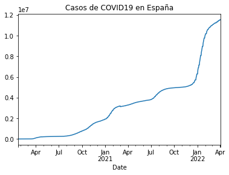

```python
df_es.set_index('Date')['Cases'].plot(title="Casos de COVID19 en España")
```

La función **title** title="xxxxx" sirve para titular el plot, o gráfico que hicimos

## Otro país

Aquí hacemos exactamente lo mismo que con España pero con Italia. Le decimos a Python que la url con la que trabajaremos es la que contiene los datos de Italia, y que lea sus datos en lenguaje json, además de hacer un **plot** (ya sabemos que es un gráfico) con la tabla de sus datos de: cases y date.

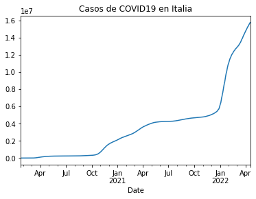

```python
url_it = 'https://api.covid19api.com/country/italy/status/confirmed/live'
df_it = pd.read_json(url_it)
df_it.set_index('Date')['Cases'].plot(title="Casos de COVID19 en Italia")
```

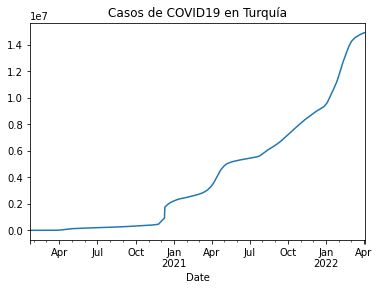

```python
url_tr = 'https://api.covid19api.com/country/turkey/status/confirmed/live'
df_tr = pd.read_json(url_tr)
df_tr.set_index('Date')['Cases'].plot(title="Casos de COVID19 en Turquía")
```

Ahora que ya hicimos lo mismo con otro país que no es españa (yo Italia), mezclaremos los tres datos de los tres países. Para eso hay que hacer una nueva tabla.

## Comparación

```python
casos_es = df_es.set_index('Date')['Cases']
casos_it = df_it.set_index('Date')['Cases']
casos_tr = df_tr.set_index('Date')['Cases']
```

Lo que acabamos de hacer ahora es decirle a Python que casos_es va a ser la tabla con los datos de casos por día que ya obtuvimos antes y a través de la que creamos el gráfico. Haremos lo mismo con Italia y Turquía para tener los tres países que irán en nuestra tabla.

```python
casos_es
```

```
Date
2020-01-22 00:00:00+00:00           0
2020-01-23 00:00:00+00:00           0
2020-01-24 00:00:00+00:00           0
2020-01-25 00:00:00+00:00           0
2020-01-26 00:00:00+00:00           0
                               ...
2022-03-30 00:00:00+00:00    11508309
2022-03-31 00:00:00+00:00    11508309
2022-04-01 00:00:00+00:00    11551574
2022-04-02 00:00:00+00:00    11551574
2022-04-03 00:00:00+00:00    11551574
Name: Cases, Length: 803, dtype: int64
```

```python
casos_it
```

```
Date
2020-01-22 00:00:00+00:00           0
2020-01-23 00:00:00+00:00           0
2020-01-24 00:00:00+00:00           0
2020-01-25 00:00:00+00:00           0
2020-01-26 00:00:00+00:00           0
                               ...
2022-03-30 00:00:00+00:00    14567990
2022-03-31 00:00:00+00:00    14642354
2022-04-01 00:00:00+00:00    14719394
2022-04-02 00:00:00+00:00    14790806
2022-04-03 00:00:00+00:00    14845815
Name: Cases, Length: 803, dtype: int64
```

Aquí lo que vamos a hacer es pedirle a pandas que lleve a cabo la función "concat" para que concatene los datos de ambos países; los días x nº de casos

```python
pd.concat([casos_es,casos_it,casos_tr], axis=1)
```

| Date | Cases | Cases | Cases |
| --- | --- | --- | --- |
| 2020-01-22 00:00:00+00:00 | 0.0 | 0.0 | 0 |
| 2020-01-23 00:00:00+00:00 | 0.0 | 0.0 | 0 |
| 2020-01-24 00:00:00+00:00 | 0.0 | 0.0 | 0 |
| 2020-01-25 00:00:00+00:00 | 0.0 | 0.0 | 0 |
| 2020-01-26 00:00:00+00:00 | 0.0 | 0.0 | 0 |
| ... | ... | ... | ... |
| 2022-03-31 00:00:00+00:00 | 11508309.0 | 14642354.0 | 14860560 |
| 2022-04-01 00:00:00+00:00 | 11551574.0 | 14719394.0 | 14873927 |
| 2022-04-02 00:00:00+00:00 | 11551574.0 | 14790806.0 | 14885710 |
| 2022-04-03 00:00:00+00:00 | 11551574.0 | 14845815.0 | 14894731 |
| 2022-04-04 00:00:00+00:00 | NaN | NaN | 14894731 |

804 rows × 3 columns

Ahora, lo que hacemos es abreviar toda la función de concatenación hecha antes de los tres conjuntos de datos como **vs**:

```python
vs=pd.concat([casos_es,casos_it,casos_tr], axis=1)
vs
```

| Date | Cases | Cases | Cases |
| --- | --- | --- | --- |
| 2020-01-22 00:00:00+00:00 | 0.0 | 0.0 | 0 |
| 2020-01-23 00:00:00+00:00 | 0.0 | 0.0 | 0 |
| 2020-01-24 00:00:00+00:00 | 0.0 | 0.0 | 0 |
| 2020-01-25 00:00:00+00:00 | 0.0 | 0.0 | 0 |
| 2020-01-26 00:00:00+00:00 | 0.0 | 0.0 | 0 |
| ... | ... | ... | ... |
| 2022-03-31 00:00:00+00:00 | 11508309.0 | 14642354.0 | 14860560 |
| 2022-04-01 00:00:00+00:00 | 11551574.0 | 14719394.0 | 14873927 |
| 2022-04-02 00:00:00+00:00 | 11551574.0 | 14790806.0 | 14885710 |
| 2022-04-03 00:00:00+00:00 | 11551574.0 | 14845815.0 | 14894731 |
| 2022-04-04 00:00:00+00:00 | NaN | NaN | 14894731 |

804 rows × 3 columns

Después de organizar los datos de vs en columnas con "vs.columns", le pedimos que lo resuma de forma gráfica con plot de nuevo:

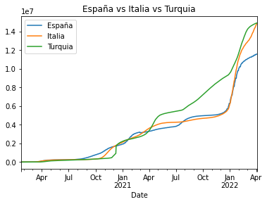

```python
vs.columns = ['España','Italia','Turquia']
vs.plot(title='España vs Italia vs Turquia')
```

### Guardar el progreso

```python
vs.to_csv('esvsit.csv')
```

```python
!ls
```

```
esvsit.csv  python-api-covid19-pandas.ipynb  Shared_Resources  Untitled.ipynb
```

```
---------------------------------------------------------------------------
AttributeError                            Traceback (most recent call last)
<ipython-input-62-0fa8fbafd9b3> in <module>
      1 import matplotlib as plt
      2 vs.plot()
----> 3 plt.savefig('esvsit.png')

AttributeError: module 'matplotlib' has no attribute 'savefig'
```

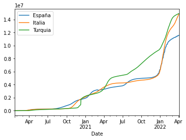

```python
import matplotlib as plt
vs.plot()
plt.savefig('esvsit.png')
```

```python
ls
```

```
esvsit.csv  python-api-covid19-pandas.ipynb  Shared_Resources@  Untitled.ipynb
```